```r
studentPerf <- read.csv("StudentsPerformance.csv")
```

Analyse descriptive

Ici “gender” est une variable binaire, “race.ethnicity”, “parental.level.of.education”, “lunch” et “test.preparation.course” sont des variables qualitative nominales Les variables “math.score”, “reading.score”, “writing.score” sont quantitatives discrÃ¨tes.

```r
summary(studentPerf)
```

```
##     gender    race.ethnicity     parental.level.of.education
##  female:518   group A: 89    associate's degree:222
##  male  :482   group B:190    bachelor's degree :118
##               group C:319    high school       :196
##               group D:262    master's degree   : 59
##               group E:140    some college      :226
##                              some high school  :179
##           lunch     test.preparation.course   math.score
##  free/reduced:355   completed:358           Min.   :  0.00
##  standard    :645   none     :642           1st Qu.: 57.00
##                                             Median : 66.00
##                                             Mean   : 66.09
##                                             3rd Qu.: 77.00
##                                             Max.   :100.00
##  reading.score    writing.score
##  Min.   : 17.00   Min.   : 10.00
##  1st Qu.: 59.00   1st Qu.: 57.75
##  Median : 70.00   Median : 69.00
##  Mean   : 69.17   Mean   : 68.05
##  3rd Qu.: 79.00   3rd Qu.: 79.00
##  Max.   :100.00   Max.   :100.00
```

Nous remarquons qu’il n’y a pas de valeurs manquantes dans ce jeu de donnÃ©es.

Les scores aux trois Ã©preuves “math.score”, reading.score" et “writing.score” varient respectivement dans [[0;100]], [[17;100]] et [[10;100]].

```r
levels(studentPerf$gender)
```

```
## [1] "female" "male"
```

“gender” varie entre “female” et “male”, c’est donc une variable binaire

```r
levels(studentPerf$lunch)
```

```
## [1] "free/reduced" "standard"
```

“lunch” varie entre “free/reduced” et “standard”

```r
levels(studentPerf$race.ethnicity)
```

```
## [1] "group A" "group B" "group C" "group D" "group E"
```

“race.ethnicity” varie entre “group A”, “group B”, “group C”, “group D” et “group E”

```r
levels(studentPerf$parental.level.of.education)
```

```
## [1] "associate's degree" "bachelor's degree"  "high school"
## [4] "master's degree"    "some college"       "some high school"
```

“parental.level.of.education” varie entre “associate’s degree”, “bachelor’s degree”, “high school”, “master’s degree”, “some college” et “some high school”

Nous étudions maintenant les liens statistiques entre les différentes variables.

Analyses multivariÃ©es

Tests préalables : Test de normalité et d’homoscédasticité 1)Test de normalité On vérifie que les données sont gaussiennes

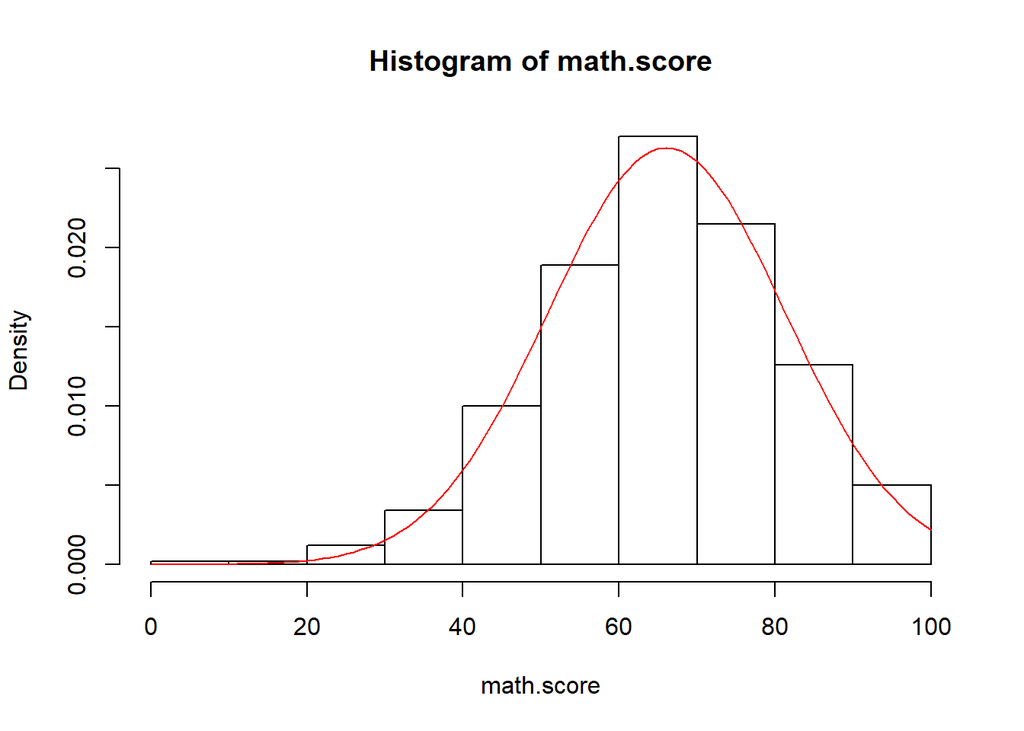

```r
hist(studentPerf$math.score,prob=T, main = "Histogram of math.score", xlab = "math.score")
curve(dnorm(x,mean(studentPerf$math.score),sd(studentPerf$math.score)), add=T,col="red")
```

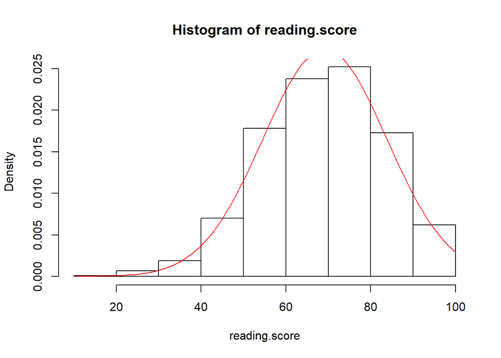

```r
hist(studentPerf$reading.score,prob=T,main = "Histogram of reading.score", xlab = "reading.score")
curve(dnorm(x,mean(studentPerf$reading.score),sd(studentPerf$reading.score)), add=T,col="red")
```

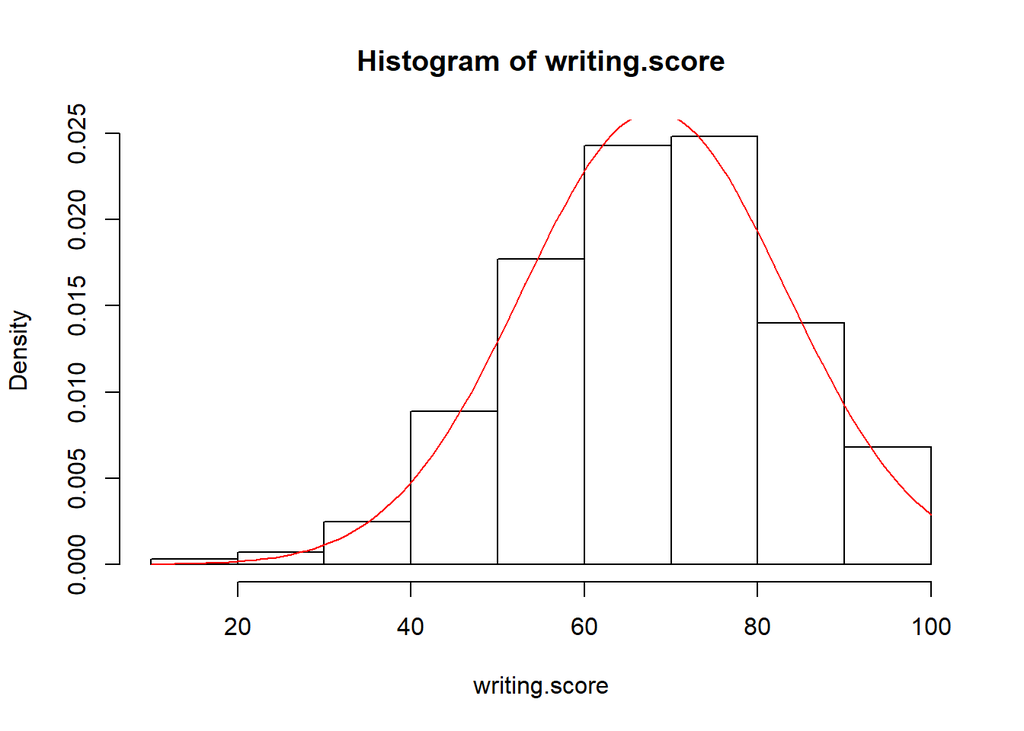

```r
hist(studentPerf$writing.score,prob=T,main = "Histogram of writing.score", xlab = "writing.score")
curve(dnorm(x,mean(studentPerf$writing.score),sd(studentPerf$writing.score)), add=T,col="red")
```

Les données semblent être gaussiennes, nous effectuons alors un test de normalité afin de le vérifier. La taille de l’échantillon (1000 individus) est petite (<2000). Le test de Shapiro-Wilk est donc adaptée.

```r
shapiro.test(studentPerf$math.score)
```

```
##
##  Shapiro-Wilk normality test
##
## data:  studentPerf$math.score
## W = 0.99315, p-value = 0.0001455
```

Le test de Shapiro-Wilk donne une probabilité de dépassement de 0.0001455, inférieure au seuil de signification de 5%. L’hypothèse de normalité de math.score est donc rejetée.

```r
shapiro.test(studentPerf$reading.score)
```

```
##
##  Shapiro-Wilk normality test
##
## data:  studentPerf$reading.score
## W = 0.99292, p-value = 0.0001055
```

Le test de Shapiro-Wilk donne une probabilité de dépassement de 0.0001055, inférieure au seuil de signification de 5%. L’hypothèse de normalité de reading.score est donc rejetée.

```r
shapiro.test(studentPerf$writing.score)
```

```
##
##  Shapiro-Wilk normality test
##
## data:  studentPerf$writing.score
## W = 0.99196, p-value = 2.922e-05
```

Le test de Shapiro-Wilk donne une probabilité de dépassement de 2.922e-05, inférieure au seuil de signification de 5%. L’hypothèse de normalité de writing.score est donc rejetée.

NOTE : Les données ne sont pas normales d’après le test de Shapiro-Wilk mais on fera tout de même un test ANOVA sur les données, ce test étant robuste même si les données ne sont pas tout Ã fait normales.

2)Test d’homoscédasticité

```r
bartlett.test(math.score~gender,data=studentPerf)
```

```
##
##  Bartlett test of homogeneity of variances
##
## data:  math.score by gender
## Bartlett's K-squared = 2.8752, df = 1, p-value = 0.08995
```

```r
bartlett.test(reading.score~gender,data=studentPerf)
```

```
##
##  Bartlett test of homogeneity of variances
##
## data:  reading.score by gender
## Bartlett's K-squared = 0.49479, df = 1, p-value = 0.4818
```

p-value = 0.4818 > 5% => On ne rejette pas H0, on ne rejette donc pas lâhypothèse dâhomoscédasticité pour reading.score.

```r
bartlett.test(writing.score~gender,data=studentPerf)
```

```
##
##  Bartlett test of homogeneity of variances
##
## data:  writing.score by gender
## Bartlett's K-squared = 1.2674, df = 1, p-value = 0.2603
```

p-value = 0.2603 > 5% => On ne rejette pas H0, on ne rejette donc pas lâhypothèse dâhomoscédasticité pour writing.score.

Les variances des trois scores sont donc homogÃ¨nes.

Analyse multivariÃ©e des scores en fonction du genre

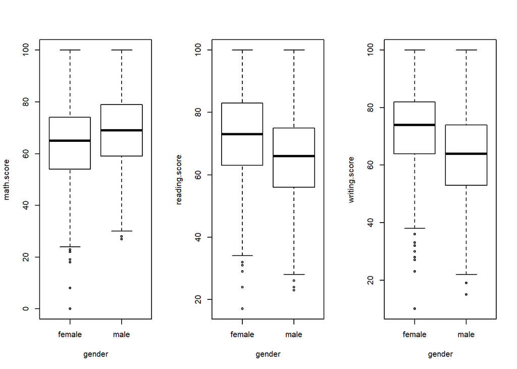

```r
cols = names(studentPerf)
def.par <-par(no.readonly=T)
par(mfrow=c(1,3))
for(i in 6:8) {
  plot(studentPerf[,i]~studentPerf$gender, xlab = "gender", ylab = cols[i])
}
```

Il semble y avoir une différence notable entre les hommes et les femmes pour les scores reading.score et writing.score. Il semble aussi qu’il y a une légère différence pour le score math.score en fonction du genre. Pour confirmer ou infirmer ces résultats, nous effectuons des ANOVA: Ici et dans la suite du projet, nous fixerons le seuil alpha* Ã 5%

```r
for(i in 6:8) {
  model = lm(studentPerf[,i]~1+gender, data = studentPerf)
  print(anova(model))
}
```

```
## Analysis of Variance Table
##
## Response: studentPerf[, i]
##            Df Sum Sq Mean Sq F value   Pr(>F)
## gender      1   6481  6481.4  28.979 9.12e-08 ***
## Residuals 998 223208   223.7
## ---
## Signif. codes:  0 '***' 0.001 '**' 0.01 '*' 0.05 '.' 0.1 ' ' 1
## Analysis of Variance Table
##
## Response: studentPerf[, i]
##            Df Sum Sq Mean Sq F value    Pr(>F)
## gender      1  12711 12710.8  63.351 4.681e-15 ***
## Residuals 998 200242   200.6
## ---
## Signif. codes:  0 '***' 0.001 '**' 0.01 '*' 0.05 '.' 0.1 ' ' 1
## Analysis of Variance Table
##
## Response: studentPerf[, i]
##            Df Sum Sq Mean Sq F value    Pr(>F)
## gender      1  20931 20930.8  99.592 < 2.2e-16 ***
## Residuals 998 209746   210.2
## ---
## Signif. codes:  0 '***' 0.001 '**' 0.01 '*' 0.05 '.' 0.1 ' ' 1
```

ANOVA sur math.score en fonction de gender : p-value = 9.12e-08 < 5% => on rejette H0. ANOVA sur reading.score en fonction de gender : p-value = 4.681e-15 < 5% => on rejette H0. ANOVA sur writing.score en fonction de gender : p-value = 2.2e-16 < 5% => on rejette H0. Il y a donc une diffÃ©rence significative entre les hommes et les femmes pour chacun des scores: math.score, reading.score et writing.score.

Analyse multivariÃ©e des scores en fonction du groupe ethnique

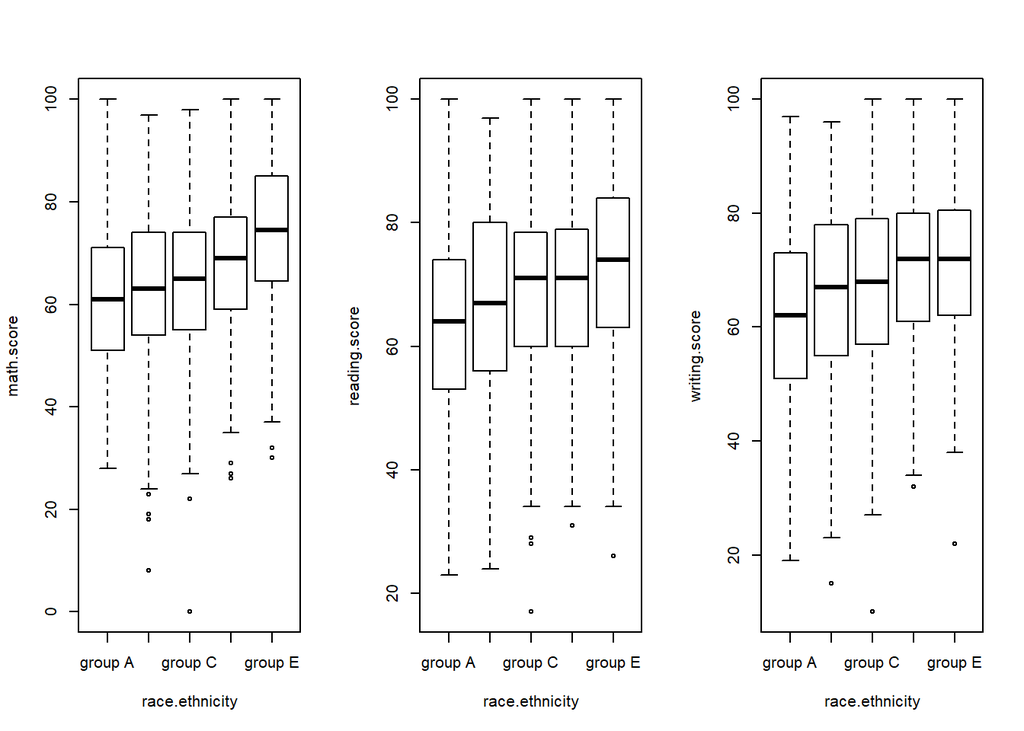

```r
cols = names(studentPerf)
def.par <-par(no.readonly=T)
par(mfrow=c(1,3))
for(i in 6:8) {
  plot(studentPerf[,i]~studentPerf$race.ethnicity, xlab = "race.ethnicity", ylab = cols[i])
}
```

Pour chacun des 3 scores, il semble y avoir des différences en fonction de l’ethnie de l’étudiant. Les scores semblent être d’autant plus élévés que l’étudiant appartient au groupe E, puis D etc. jusqu’au groupe A dont les scores semblent êtres les moins élevés.

Pour confirmer ou infirmer ces rÃ©sultats, nous effectuons des ANOVA:

```r
for(i in 6:8) {
  model = lm(studentPerf[,i]~1+race.ethnicity, data = studentPerf)
  print(anova(model))
}
```

```
## Analysis of Variance Table
##
## Response: studentPerf[, i]
##                 Df Sum Sq Mean Sq F value    Pr(>F)
## race.ethnicity   4  12729  3182.2  14.594 1.373e-11 ***
## Residuals      995 216960   218.1
## ---
## Signif. codes:  0 '***' 0.001 '**' 0.01 '*' 0.05 '.' 0.1 ' ' 1
## Analysis of Variance Table
##
## Response: studentPerf[, i]
##                 Df Sum Sq Mean Sq F value   Pr(>F)
## race.ethnicity   4   4706 1176.57  5.6217 0.000178 ***
## Residuals      995 208246  209.29
## ---
## Signif. codes:  0 '***' 0.001 '**' 0.01 '*' 0.05 '.' 0.1 ' ' 1
## Analysis of Variance Table
##
## Response: studentPerf[, i]
##                 Df Sum Sq Mean Sq F value    Pr(>F)
## race.ethnicity   4   6456 1614.03  7.1624 1.098e-05 ***
## Residuals      995 224221  225.35
## ---
## Signif. codes:  0 '***' 0.001 '**' 0.01 '*' 0.05 '.' 0.1 ' ' 1
```

ANOVA sur math.score en fonction de race.ethnicity : p-value = 1.373e-11 < 5% => on rejette H0. ANOVA sur reading.score en fonction de race.ethnicity : p-value = 0.000178 < 5% => on rejette H0. ANOVA sur writing.score en fonction de race.ethnicity : p-value = 1.098e-05 < 5% => on rejette H0. Il y a donc une différence significative entre les groupes d’ethnie différente pour chacun des scores: math.score, reading.score et writing.score.

Analyse multivariée des scores en fonction du niveau d’éducation des parents

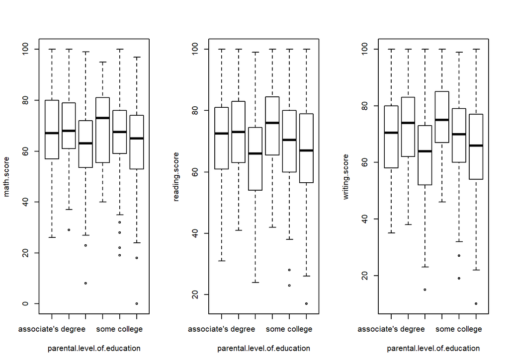

```r
cols = names(studentPerf)
def.par <-par(no.readonly=T)
par(mfrow=c(1,3))
for(i in 6:8) {
  plot(studentPerf[,i]~studentPerf$parental.level.of.education, xlab = "parental.level.of.education", ylab = cols[i])
}
```

Pour chacun des 3 scores, les scores des étudiants dont le niveau d’éducation des parents correspond Ã high school ou some high school (ce qui correspond au niveau bac) semblent se détacher avec des scores plus faibles en général. Pour confirmer ou infirmer ces résultats, nous effectuons des ANOVA :

```r
for(i in 6:8) {
  model = lm(studentPerf[,i]~1+parental.level.of.education, data = studentPerf)
  print(anova(model))
}
```

```
## Analysis of Variance Table
##
## Response: studentPerf[, i]
##                              Df Sum Sq Mean Sq F value    Pr(>F)
## parental.level.of.education   5   7296 1459.11  6.5216 5.592e-06 ***
## Residuals                   994 222394  223.74
## ---
## Signif. codes:  0 '***' 0.001 '**' 0.01 '*' 0.05 '.' 0.1 ' ' 1
## Analysis of Variance Table
##
## Response: studentPerf[, i]
##                              Df Sum Sq Mean Sq F value    Pr(>F)
## parental.level.of.education   5   9506 1901.30  9.2894 1.168e-08 ***
## Residuals                   994 203446  204.67
## ---
## Signif. codes:  0 '***' 0.001 '**' 0.01 '*' 0.05 '.' 0.1 ' ' 1
## Analysis of Variance Table
##
## Response: studentPerf[, i]
##                              Df Sum Sq Mean Sq F value   Pr(>F)
## parental.level.of.education   5  15623 3124.65  14.442 1.12e-13 ***
## Residuals                   994 215054  216.35
## ---
## Signif. codes:  0 '***' 0.001 '**' 0.01 '*' 0.05 '.' 0.1 ' ' 1
```

ANOVA sur math.score en fonction de parental.level.of.education : p-value = 5.592e-06 < 5% => on rejette H0. ANOVA sur reading.score en fonction de parental.level.of.education : p-value = 1.168e-08 < 5% => on rejette H0. ANOVA sur writing.score en fonction de parental.level.of.education : p-value = 1.12e-13 < 5% => on rejette H0. Il y a donc une différence significative entre les groupes de niveau d’éducation des parents est différent pour chacun des scores: math.score, reading.score et writing.score.

# Analyse multivariée des scores en fonction du type de déjeuner (gratuit/tarif réduit ou standard)

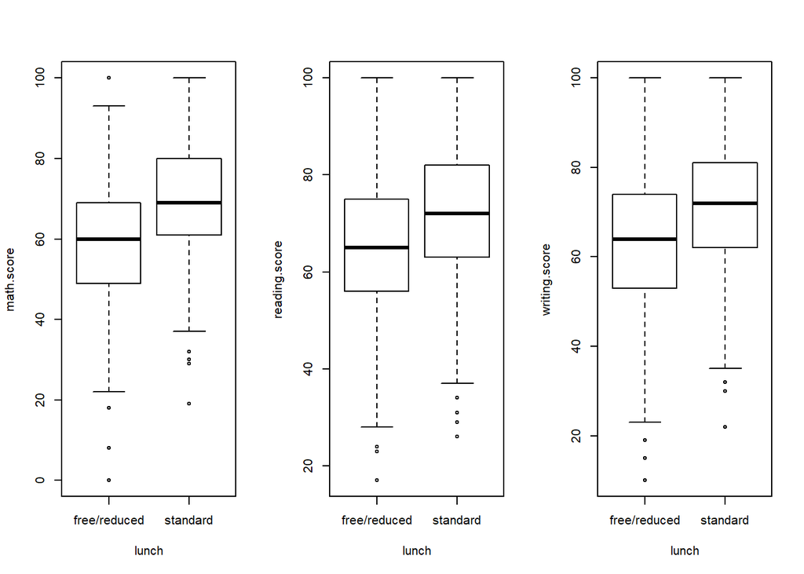

```r
cols = names(studentPerf)
def.par <-par(no.readonly=T)
par(mfrow=c(1,3))
for(i in 6:8) {
  plot(studentPerf[,i]~studentPerf$lunch, xlab = "lunch", ylab = cols[i])
}
```

Pour chacun des 3 scores, il semble y avoir une différence notable en fonction du déjeuner. Ceux ayant un déjeuner standard semblent avoir de meilleurs résultat. Interessant de voir corrélation entre type de déjeuner et niveau éducation parents car le problème vient peut etre du niveau d’éducation des parents. Pour confirmer ou infirmer ces résultats, nous effectuons des ANOVA:

```r
for(i in 6:8) {
  model = lm(studentPerf[,i]~1+lunch, data = studentPerf)
  print(anova(model))
}
```

```
## Analysis of Variance Table
##
## Response: studentPerf[, i]
##            Df Sum Sq Mean Sq F value    Pr(>F)
## lunch       1  28278 28278.0  140.12 < 2.2e-16 ***
## Residuals 998 201411   201.8
## ---
## Signif. codes:  0 '***' 0.001 '**' 0.01 '*' 0.05 '.' 0.1 ' ' 1
## Analysis of Variance Table
##
## Response: studentPerf[, i]
##            Df Sum Sq Mean Sq F value    Pr(>F)
## lunch       1  11222 11222.2  55.518 2.003e-13 ***
## Residuals 998 201730   202.1
## ---
## Signif. codes:  0 '***' 0.001 '**' 0.01 '*' 0.05 '.' 0.1 ' ' 1
## Analysis of Variance Table
##
## Response: studentPerf[, i]
##            Df Sum Sq Mean Sq F value    Pr(>F)
## lunch       1  13933 13933.4  64.157 3.186e-15 ***
## Residuals 998 216744   217.2
## ---
## Signif. codes:  0 '***' 0.001 '**' 0.01 '*' 0.05 '.' 0.1 ' ' 1
```

ANOVA sur math.score en fonction de lunch : p-value = 2.2e-16 < 5% => on rejette H0. ANOVA sur reading.score en fonction de lunch : p-value = 2.003e-13 < 5% => on rejette H0. ANOVA sur writing.score en fonction de lunch : p-value = 3.186e-15 < 5% => on rejette H0. Il y a donc une différence significative entre les groupes qui ont un déjeuner gratuit/réduit ou bien standard pour chacun des scores: math.score, reading.score et writing.score.

Analyse multivariée des scores en fonction de si l’étudiant a complété ou non un test suite Ã un cours de préparation

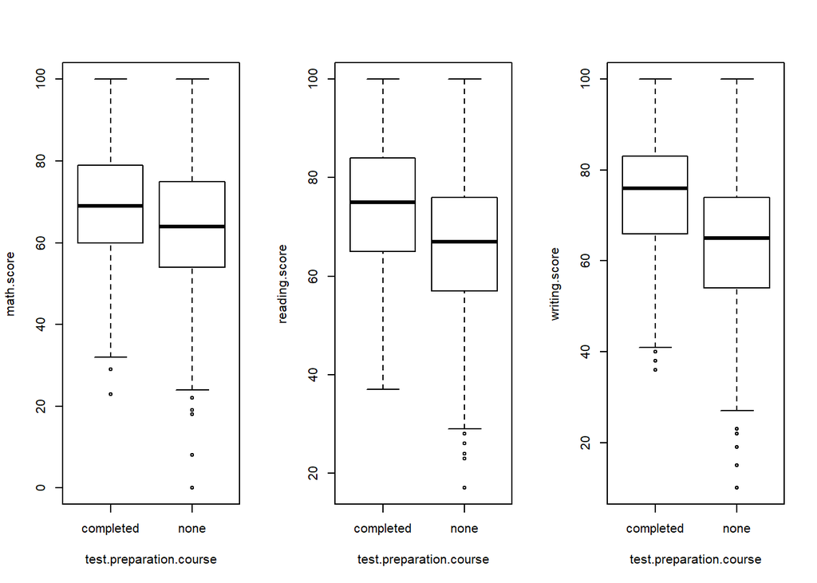

```r
cols = names(studentPerf)
def.par <-par(no.readonly=T)
par(mfrow=c(1,3))
for(i in 6:8) {
  plot(studentPerf[,i]~studentPerf$test.preparation.course, xlab = "test.preparation.course", ylab = cols[i])
}
```

Pour chacun des 3 scores, il semble y avoir une différence notable entre les étudiants ayant passés un test préparatoire ou non. Ceux ayant passés un test semblent avoir de meilleurs scores. Pour confirmer ou infirmer ces résultats, nous effectuons des ANOVA:

```r
for(i in 6:8) {
  model = lm(studentPerf[,i]~1+test.preparation.course, data = studentPerf)
  print(anova(model))
}
```

```
## Analysis of Variance Table
##
## Response: studentPerf[, i]
##                          Df Sum Sq Mean Sq F value    Pr(>F)
## test.preparation.course   1   7253  7253.2  32.543 1.536e-08 ***
## Residuals               998 222436   222.9
## ---
## Signif. codes:  0 '***' 0.001 '**' 0.01 '*' 0.05 '.' 0.1 ' ' 1
## Analysis of Variance Table
##
## Response: studentPerf[, i]
##                          Df Sum Sq Mean Sq F value    Pr(>F)
## test.preparation.course   1  12449 12448.7  61.963 9.082e-15 ***
## Residuals               998 200504   200.9
## ---
## Signif. codes:  0 '***' 0.001 '**' 0.01 '*' 0.05 '.' 0.1 ' ' 1
## Analysis of Variance Table
##
## Response: studentPerf[, i]
##                          Df Sum Sq Mean Sq F value    Pr(>F)
## test.preparation.course   1  22591 22591.4  108.35 < 2.2e-16 ***
## Residuals               998 208086   208.5
## ---
## Signif. codes:  0 '***' 0.001 '**' 0.01 '*' 0.05 '.' 0.1 ' ' 1
```

ANOVA sur math.score en fonction de test.preparation.course : p-value = 1.536e-08 < 5% => on rejette H0. ANOVA sur reading.score en fonction de test.preparation.course : p-value = 9.082e-15 < 5% => on rejette H0. ANOVA sur writing.score en fonction de test.preparation.course : p-value = 2.2e-16 < 5% => on rejette H0. Il y a donc une différence significative entre les groupes qui ont passé un test de préparation ou non pour chacun des scores: math.score, reading.score et writing.score.

```r
corMat = cor(studentPerf[,c("math.score","reading.score", "writing.score")])
corMat
```

```
##               math.score reading.score writing.score
## math.score     1.0000000     0.8175797     0.8026420
## reading.score  0.8175797     1.0000000     0.9545981
## writing.score  0.8026420     0.9545981     1.0000000
```

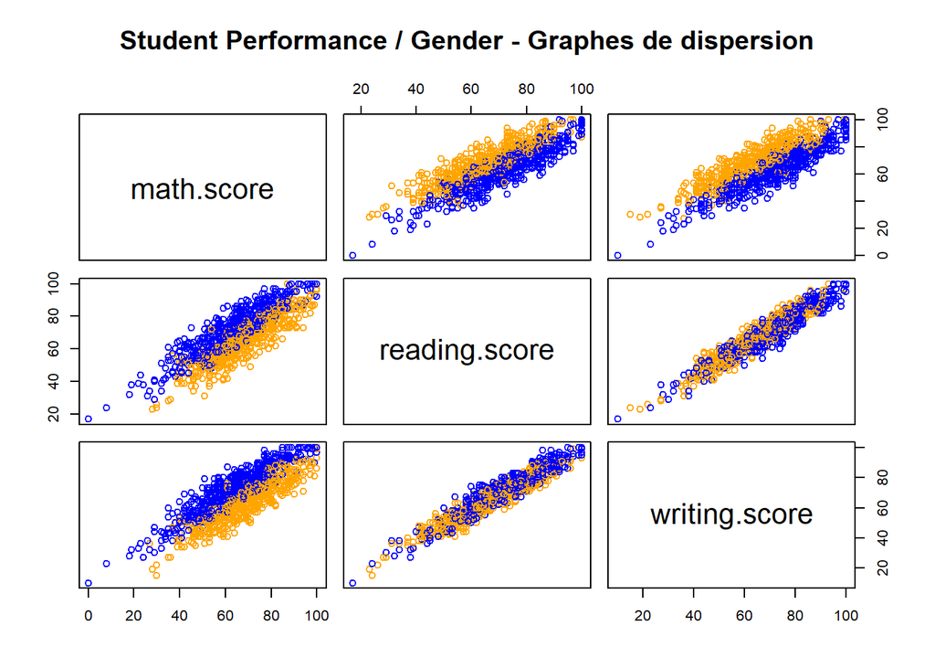

```r
pairs(studentPerf[,c("math.score","reading.score", "writing.score")],main = "Student Performance / Gender - Graphes de dispersion" ,col =c("blue","orange")[studentPerf$gender])
```

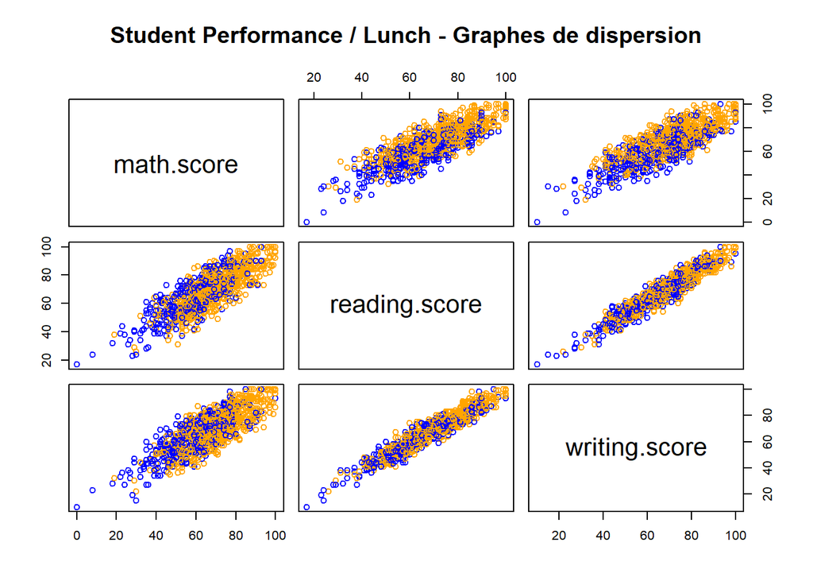

```r
pairs(studentPerf[,c("math.score","reading.score", "writing.score")],main = "Student Performance / Lunch - Graphes de dispersion" ,col =c("blue","orange")[studentPerf$lunch])
```

Les variables relatives aux scores semblent être corrélées en particulier “reading.score” et “writing.score” Ceci indique qu’un étudiant a en général des scores assez homogènes aux trois épreuves et surtout en reading et writing.

On remarque Ã©galement que deux groupes apparaissent losqu’on projettent les scores fonction du genre.

On effectue alors une ACP afin d’obtenir des variables non corrélées linéairement. On effectue une ACP sur les variables quantitatives

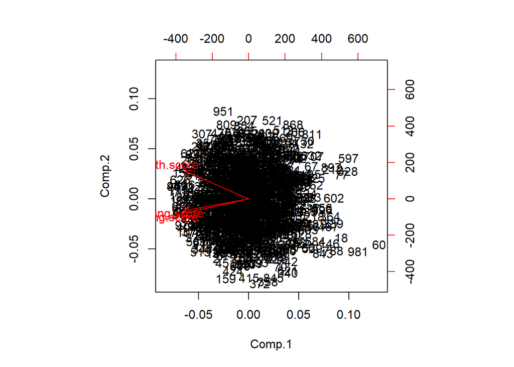

```r
studentPerf.acp = princomp(studentPerf[,c("math.score","reading.score", "writing.score")])
biplot(studentPerf.acp)
```

L’orientation des flèches confirment que reading.score et writing.score sont très corrélées.

```r
summary(studentPerf.acp)
```

```
## Importance of components:
##                            Comp.1     Comp.2     Comp.3
## Standard deviation     24.6882795 7.33923987 3.15325449
## Proportion of Variance  0.9052344 0.07999845 0.01476718
## Cumulative Proportion   0.9052344 0.98523282 1.00000000
```

On pourrait choisir de perdre l’information du troisième axe factoriel. Cela dit, nous avons choisi de garder les 3 variables initiales (avant l’ACP), le jeu de données étant déjÃ assez simple. Ceci a l’avantage de conserver la signification de chacun des scores.

classification automatique

CAH (nous servira surtout Ã determiner le nombre de classes K Ã utiliser pour appliquer l’algorithme des k-means afin d’essayer de faire une classification (clustering))

```r
#studentPerf$math.score = scale(studentPerf$math.score)
#studentPerf$reading.score = scale(studentPerf$reading.score)
#studentPerf$writing.score = scale(studentPerf$writing.score)
```

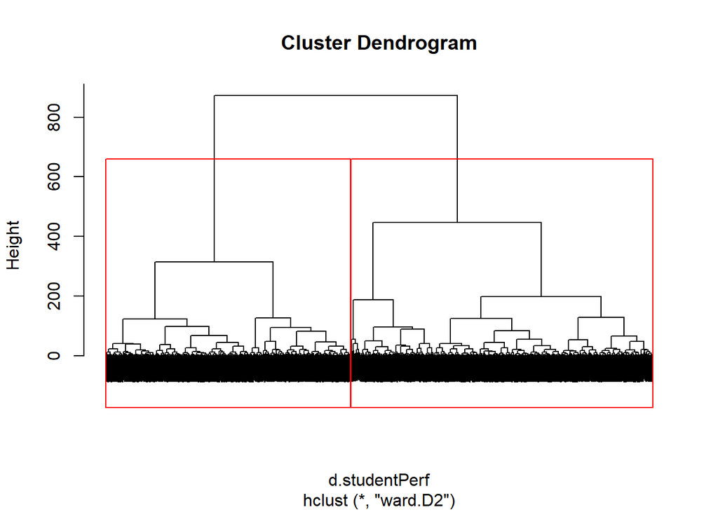

```r
d.studentPerf = dist(studentPerf[,c(6:8)])
cah.ward = hclust(d.studentPerf,method="ward.D2")
plot(cah.ward, labels = F)
rect.hclust(cah.ward,k=2)
```

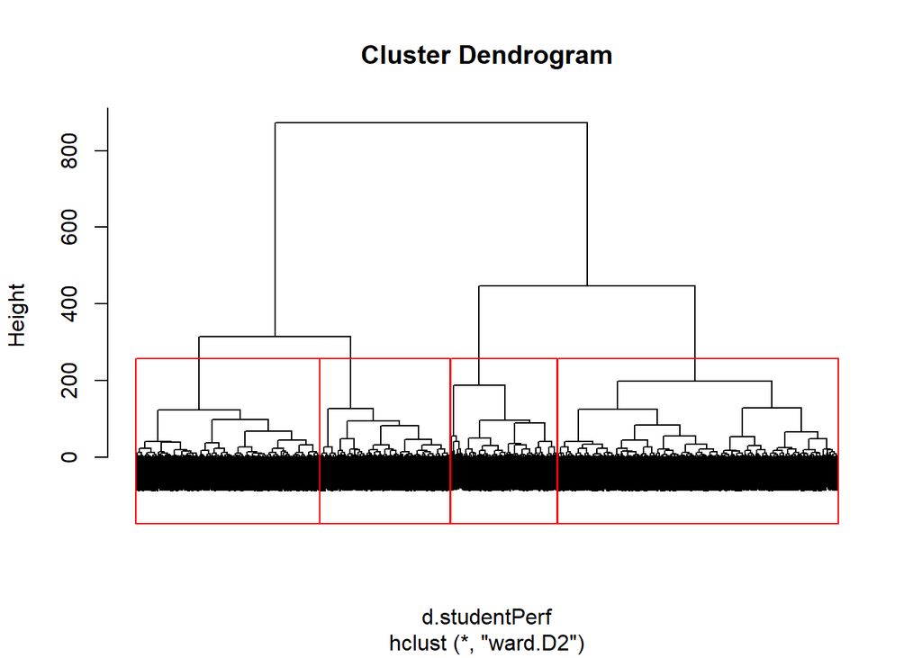

```r
plot(cah.ward, labels = F)
rect.hclust(cah.ward,k=4)
```

Etant donnÃ© ce dendogramme, il parait judicieux de prendre un niveau de regroupement tel qu’il y ait 2 ou 4 classes distinctes.

Nous appliquons alors l’algorithme des k-means avec k=2, nstart=25 pour prendre 25 configurations initiales et garder la meilleure.

```r
kmeans(studentPerf[,c(6:8)], centers = 2, nstart=25)
```

```
## K-means clustering with 2 clusters of sizes 556, 444
##
## Cluster means:
##   math.score reading.score writing.score
## 1   75.94784      79.38309      78.58993
## 2   53.74324      56.37838      54.86036
##
## Clustering vector:
##    [1] 1 1 1 2 1 1 1 2 2 2 2 2 1 1 2 1 1 2 2 2 2 1 2 1 1 1 2 1 1 1 1 2 2 2
##   [35] 1 1 1 2 1 2 2 2 2 2 2 2 2 1 1 1 2 1 2 1 1 2 1 2 2 2 1 2 2 1 2 2 2 1
##   [69] 2 2 2 2 2 2 2 2 2 1 1 2 2 2 2 2 2 1 1 1 2 1 1 2 1 2 1 1 2 1 2 2 1 1
##  [103] 1 2 1 2 1 2 2 1 1 2 2 2 1 1 1 1 2 2 1 1 1 2 1 1 1 1 1 2 1 2 1 1 1 2
##  [137] 2 2 2 1 1 2 2 2 1 2 1 1 1 1 2 1 2 2 2 1 1 2 1 2 1 1 2 2 1 1 2 1 1 1
##  [171] 1 1 1 1 2 1 2 1 2 1 1 2 2 1 2 2 1 2 2 1 1 1 2 1 1 2 2 2 2 1 1 1 1 2
##  [205] 2 1 1 1 1 2 1 2 2 2 1 1 1 2 1 2 2 1 2 1 2 2 1 2 1 1 1 2 1 1 1 1 2 2
```

[output cut: 33 more lines]

```r
kmeans(studentPerf[,c(6:8)], centers = 4, nstart=25)
```

```
## K-means clustering with 4 clusters of sizes 350, 159, 297, 194
##
## Cluster means:
##   math.score reading.score writing.score
## 1   71.09714      74.76000      73.85714
## 2   44.50314      46.98113      44.56604
## 3   59.17172      61.83502      60.89226
## 4   85.33505      88.49485      87.79897
##
## Clustering vector:
##    [1] 1 4 4 2 1 1 4 2 3 2 3 2 1 1 3 1 4 2 2 3 3 1 2 1 1 1 3 1 1 1 1 3 3 2
##   [35] 4 4 1 3 4 3 3 3 3 3 3 3 3 1 1 4 2 1 2 4 4 2 4 2 3 2 1 2 3 1 3 3 2 1
##   [69] 3 3 3 3 2 3 2 2 2 1 1 3 2 2 2 3 2 1 4 1 3 4 1 2 1 2 4 4 3 1 3 3 1 1
##  [103] 4 2 4 3 4 3 3 1 4 3 2 3 4 1 4 1 3 3 4 4 4 3 1 4 1 1 1 2 4 2 1 1 1 3
##  [137] 2 3 3 3 1 3 2 2 1 2 4 1 1 4 3 1 3 2 3 4 1 3 1 3 1 4 2 2 4 4 2 1 1 1
```

[output cut: 35 more lines]

Les clusters ainsi formés donnent des groupes de niveaux différents que l’on pourrait nommer “moyen”, “bon” “très bon” et “excellent”.